# Привлекательность и уровень заработной платы

## Постановка задачи

По 1260 опрошенным имеются следующие данные:

- заработная плата за час работы, $;
- опыт работы, лет;
- образование, лет;
- внешняя привлекательность, в баллах от 1 до 5;
- бинарные признаки: пол, семейное положение, состояние здоровья (хорошее/плохое), членство в профсоюзе, цвет кожи (белый/чёрный), занятость в сфере обслуживания (да/нет).

Требуется оценить влияние внешней привлекательности на уровень заработка с учётом всех остальных факторов.

Попарные диаграммы рассеяния всех количественных признаков:

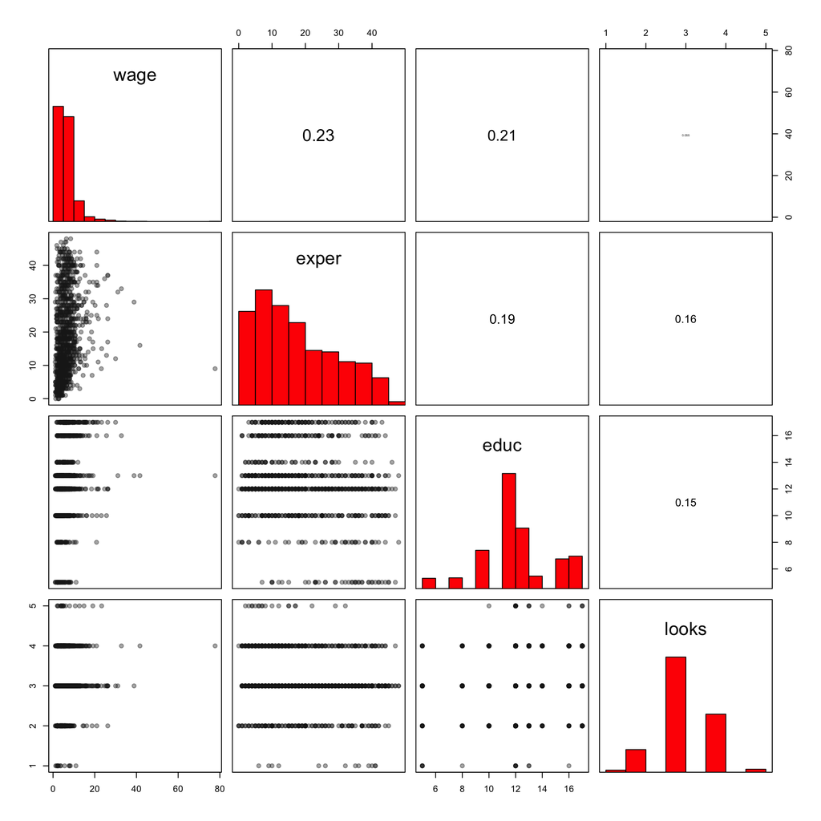

## Задание

### Предобработка

1. Посмотрите на распределение оценок привлекательности (`looks`). Сделайте из него категориальный признак, разбив на три категории (низкая привлекательность (`looks < 3`), средняя привлекательность (`looks = 3`) и высокая привлекательность (`looks > 3`))

```r
# type your code here
```

2. Посмотрите на распределение значений отклика. Есть ли в нем выбросы? Выбросы могут сильно влиять на коэффициенты регрессии и мы с вами еще рассмотрим способы выявления выбросов. Удалите наблюдения, которые вы считаете выбросами. Этот шаг нужно всегда делать осторожно, но в этих данных выбросы видны невооруженным взглядом.

```r
# Type your code here
```

3. Видно, что распределение откликов далеко от нормального, поэтому примените пробразование Бокса-Кокса с помощью функции `boxcox` из пакета `MASS`. На вход этой функции нужно передать результат выполнения вызова построения линейной регресии `lm`, где в виде формулы нужно будет закодировать зависимость отклика от всех возможных объясняющих переменных. Преобразуйте отклик согласно той трансформации, которую вы получите в результате выполнения этой функции.

```r
# Type your code here
```

### Модель 1

4. Постройте линейную регрессию по всем признакам, используя преобразованные значения отклика. Посмотрите на остатки регрессии c помощью функции `residuals(lm(...))`
- Проверьте остатки на нормальность с помощью критерия Шапиро-Уилка.
  - Если гипотеза нормальности отвергается, то для проверки несмещенности воспользуейтесь критерием знаковых рангов Уилкоксона (`wilcox.test`), не забыв при этом отключить коррекцию на непрерывность.
  - Если гипотеза нормальности не отвергается, то воспользуйтесь критерием Стьюдента.
- С помощью критерия Бройша-Пагана (`bptest` из `lmtest`) проверьте модель на наличие гетероскедастичности.

```r
# Type your code here
```

5. Если гипотеза об отсутсвии гетероскедастичности отвергается, то рекомендуется воспользоваться специальным подходом отбора признаков, который был на лекции и который реализует функция `mycoeftest`. Вторым аргументом в эту функцию нужно передать строку `"HC0"`, которая соответствует устойчивой оценке дисперсии Уайта. Получите с помощью функции `mycoeftest` значения достигаемых уровней значимости, скорректированных на множественную проверку гипотез.

```r
# Type your code here
```

6. Проведите визуальный анализ остатков.
- проведите визуальный анализ нормальности остатков с помощью функции `qqnorm / qqline`
- нарисуйте график зависимости нормализованных значений остатков `rstudent(lm(...))` от каждого из признаков и добавьте тренд к каждому из графиков с помощью функции `addtrend`. Видите ли вы какие-то зависимости, которые можно было бы добавить к исходному набору признаков?

```r
# Type your code here
```

### Модель 2

7. Добавьте в линейную модель новый признак - квадрат опыта работы, положив в вызове функции `lm` формулу равной `logwage ~ . + I(exper^2)`. Здесь функция `I()` экранирует вычисление поэлементного возведения в степень от логики обработки формул в R. Если не написать внешнее `I()`, то в модели окажется не квадрат `exper`, а взаимодействие между всеми элементами, которые возводятся в степень. То есть, поскольку у нас возводится только один элемент в степень, то и никаких дополнительных взаимодействий в модель добавлено не будет.

```r
# Type your code here
```

8. Убедитесь аналогично тому, как вы это делали ранее, что остатки этой регрессии ненормальны и гетерскедастичны. А также осуществите отбор признаков с учетом множестенной проверки гипотез (так же, как в предыдущем пункте). Какие признаки оказались незначимы?

```r
# Type your code here
```

9. Проведите визуальный анализ нормальности остатков и зависимостей остатков от каждого из признаков в модели, которую вы построили. Можно ли еще добавить какие-либо преобразования признаков, которые улучшат эти зависимости?

```r
# Type your code here
```

10. Прежде чем удалять незначимые признаки, следует проверить, что что эти признаки не входят в значимые взаимодействия с другими признаками. Для этого воспользуйстесь функцией `add1`, которой передайте формулу `~ .^2` (что означает взять все возможные взаимодействия в модели, которую вы передадите первым аргументом) и укажите аргумент `test="F"`

```r
# Type your code here
```

### Модель 3

11. Удалите из из модели 2 незначимые признаки и добавьте взаимодействие пола и опыта работы, а также добавьте в модель `aboveavg`. Проверьте остатки на нормальность, несмещенность и гетероскедастичность. Проверьте коэффициенты на значимость с учетом коррекции на множественное сравнение.

```r
# Type your code here
```

12. Сравните модель 2 с моделью 3 при помощью критерия Давидсона-Маккинона, который реализует функция `jtest` из пакета `lmtest`. Какая из двух моделей лучше ?

```r
# Type your code here
```

### Модель 4

13. Попробуем оставить в модели 2 цвет кожи и семейное положение, чтобы добавить их взаимодействия с полом. Как и в модели 3, добавьте взаимодействие пола с опытом работы, удалите состояние здоровья и добавьте `aboveavg`.

```r
# Type your code here
```

14. Проверьте остатки на нормальность, несмещенность и гетероскедастичность. Проверьте коэффициенты на значимость с учетом коррекции на множественное сравнение.

```r
# Type your code here
```

15. Проведите визуальный анализ остатков для построенной Вами модели.

```r
# Type your code here
```

16. Сравните построенную модель с моделью 3 c помощью критерия Вальда с дисперсиями Уайта (в случае гетероскедастичности). В этом Вам поможет функция `waldtest` из пакета `lmtest`. Обатите внимание на параметр `vcov=vcovHC(lm(..), type="HC0")`. Получается ли значимо лучше, чем модель 3?

```r
# Type your code here
```

17. Посмотрите, есть ли еще значимые взаимодействия, которые можно добавить в модель (функция `add1`). Рассмотрите только те взаимодействия, которые значимы на уровне 0.01. Если таких не окажется, переходите к следующему пункту. Кроме того, стоит избегать сложных взаимодействий, которые затруднительно интепретировать (например, взаимодействие квадрата опыта и цвета кожи).

```r
# Type your code here
```

### Модель 5

18. Есть ли в предыдущей модели такие признаки, которые не значимы сами по себе, а также незначимы их взаимодействия? Попробуйте удалить их из модели (как отдельные признаки, так и их взаимодействия). Сравните получившуюся модель с моделью 4 при помощью теста Вальда.

```r
# Type your code here
```

19. Попробуйте удалить из модели только незначимые взаимодействия. Сравните получившуюся модель с моделью 4 при помощью критерия Вальда. На какой модели Вы бы предложили остановиться?

```r
# Type your code here
```

# Расстояние Кука

20. Нарисуйте график, на котором по горизонтальной оси отложите предсказанные с помощью 4ой модели значения отклика для тех данных, с которыми мы работаем (можете воспользоваться функцией `fitted`), а по вертикальной оси - расстояния Кука (`cooks.distance` из пакета `stats`). Визуально выберите порог, по котрому удалите все слишком влиятельные точки.

```r
# Type your code here
```

21. Постройте модель, аналогичную модели 4, но с удаленными влиятельными наблюдениями. Изменились ли коэффициенты при различных признаках? Проверьте гипотезу о значимости коэффициентов в модели с использованием коррекции на множественное сравнение.

```r
# Type your code here
```

22. Остановитесь на лучшей, на Ваш взгляд модели и проинтерпретируйте коэффициенты перед интересующими нас признаками: что можно сказать о том, как влияет внешность на зарплату? В ответе на этот вопрос воспользуйтесь функцией `confint` для постоения доверительных интервалов для коэффициентов в модели.

```r
# Type your code here
```

Hamermesh D.S., Biddle J.E. (1994) **Beauty and the Labor Market**, American Economic Review, 84, 1174–1194.